# Chapter 1 — Introduction

STA5001 R Computational Companion

STA5001 Bayesian & Computational Statistics

Work through the examples in order. Section numbers follow the STA5001 lecture notes, which develop the models and algorithms used here. Open `chapter-01.Rmd` in RStudio and choose **Knit** to reproduce the outputs. Install BayesComp with `remotes::install_github("sj156/BayesComp")` to use the lecture-note figures included in this chapter.

# Section 1.1 — Updating, evidence, and prediction

**Concept.** Bayes’ rule reweights prior probabilities by the likelihood. The normalizing constant is the probability of the observed sequence under the whole model. Prediction then averages over the posterior.

**Example.** Choose one of two coins with equal prior probability. The two coins have head probabilities 1/4 and 3/4. Observe two heads followed by a tail.

The code computes the likelihood of the ordered sequence for each coin, sums the prior-weighted likelihoods to find the evidence, and then uses the posterior weights to predict the next toss.

```r
coin_values <- c(1/4, 3/4)
coin_prior <- c(1/2, 1/2)
coin_data <- c(1,1,0)
coin_likelihood <- coin_values^sum(coin_data) *
  (1-coin_values)^(length(coin_data)-sum(coin_data))
coin_joint <- coin_prior * coin_likelihood
coin_evidence <- sum(coin_joint)
coin_posterior <- coin_joint / coin_evidence
knitr::kable(data.frame(theta=coin_values, prior=coin_prior,
                       likelihood=coin_likelihood, posterior=coin_posterior))
```

| theta | prior | likelihood | posterior |
| --- | --- | --- | --- |
| 0.25 | 0.5 | 0.046875 | 0.25 |
| 0.75 | 0.5 | 0.140625 | 0.75 |

```r
coin_prediction <- sum(coin_values * coin_posterior)
c(evidence=coin_evidence, next_head=coin_prediction)
```

```
##  evidence next_head
##   0.09375   0.62500
```

```r
stopifnot(abs(coin_evidence-3/32)<1e-12,
          max(abs(coin_posterior-c(1/4,3/4)))<1e-12,
          abs(coin_prediction-5/8)<1e-12)
```

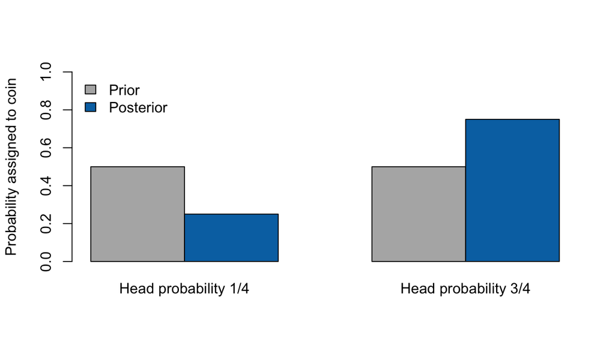

```r
barplot(rbind(coin_prior, coin_posterior), beside = TRUE,
        names.arg = c("Head probability 1/4", "Head probability 3/4"),
        col = c("grey70", "#0072B2"), ylim = c(0, 1),
        ylab = "Probability assigned to coin")
legend("topleft", c("Prior", "Posterior"),
       fill = c("grey70", "#0072B2"), bty = "n")
```

A posterior probability of `3/4` for the high-bias coin is different from the predictive probability `5/8` of the next head. **Extension:** change its prior probability to `1/5`; verify that the data still favor it even though it remains less probable after updating.

# Section 1.2 — Prior strength and predictive uncertainty

**Concept.** Two Beta priors can have the same mean and different strengths. Their total shape parameters determine how much weight the sample receives in the posterior mean.

**Example.** Use 100 hypothetical infection tests, all negative. These counts are a sufficient summary under the common-rate Bernoulli model. The two priors below have the same mean, 0.001, and different strength.

Add the observed successes and failures to each prior. The ratio of beta functions gives the probability of no infections among the next 100 people after integrating over the shared rate.

```r
s12_n <- 100; s12_successes <- 0
s12_a0 <- c(.1,1); s12_b0 <- c(99.9,999)
s12_an <- s12_a0+s12_successes
s12_bn <- s12_b0+s12_n-s12_successes
knitr::kable(data.frame(prior_mean=s12_a0/(s12_a0+s12_b0),
 concentration=s12_a0+s12_b0, posterior_mean=s12_an/(s12_an+s12_bn),
 data_weight=s12_n/(s12_n+s12_a0+s12_b0)))
```

| prior_mean | concentration | posterior_mean | data_weight |
| --- | --- | --- | --- |
| 0.001 | 100 | 0.0005000 | 0.5000000 |
| 0.001 | 1000 | 0.0009091 | 0.0909091 |

```r
s12_m <- 100
s12_any <- 1-exp(lbeta(s12_an,s12_bn+s12_m)-lbeta(s12_an,s12_bn))
s12_any
```

```
## [1] 0.03982367 0.08340284
```

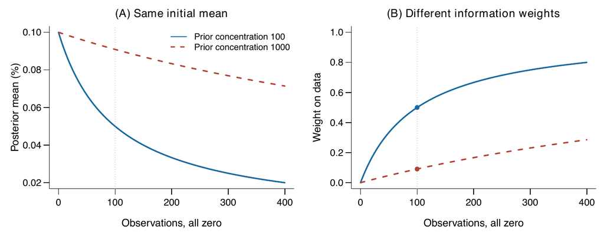

Lecture notes, Section 1.2. The vertical guides mark 100 observations.

```r
stopifnot(abs(s12_any[2]-100/1199)<1e-12)
```

Zero observed infections do not imply zero predictive risk. These calculations cannot repair an unrepresentative sample. **Extension:** compare with priors `Beta(1,99)` and `Beta(1,999)` and explain why that comparison changes both location and strength.

# Section 1.3 — Independent Monte Carlo and predictive replication

**Concept.** Independent posterior draws turn posterior expectations into sample averages. The Monte Carlo standard error measures the precision of those averages for a given simulation budget.

**Example.** Observe seven successes in ten trials under a uniform prior. Estimate the posterior mean and the probability that the success rate exceeds one half, then predict the count in five new trials.

Draw from the `Beta(8,4)` posterior and compute two sample averages, one for the rate and one for the threshold indicator. Compare each with its exact value and use the corresponding sample standard deviation to estimate its Monte Carlo standard error.

```r
set.seed(20260927)
s13_S <- 20000
s13_theta <- rbeta(s13_S,8,4)
s13_h <- as.numeric(s13_theta > .5)
s13_est <- c(mean=mean(s13_theta), probability=mean(s13_h))
s13_mcse <- c(mean=sd(s13_theta), probability=sd(s13_h))/sqrt(s13_S)
s13_exact <- c(mean=2/3, probability=227/256)
knitr::kable(data.frame(target=names(s13_est), estimate=s13_est,
 exact=s13_exact, MCSE=s13_mcse,
 error_in_MCSE=(s13_est-s13_exact)/s13_mcse),row.names=FALSE)
```

| target | estimate | exact | MCSE | error_in_MCSE |
| --- | --- | --- | --- | --- |
| mean | 0.6667436 | 0.6666667 | 0.0009283 | 0.0829009 |
| probability | 0.8868000 | 0.8867188 | 0.0022404 | 0.0362653 |

```r
c(posterior_SD=sqrt(2/117), simulated_SD=sd(s13_theta))
```

```
## posterior_SD simulated_SD
##    0.1307441    0.1312783
```

```r
stopifnot(all(abs(s13_est-s13_exact)<6*s13_mcse))
# Generalized inverse of the empirical cdf: no interpolation.
quantile(s13_theta,c(.025,.975),type=1)
```

```
##      2.5%     97.5%
## 0.3867994 0.8907272
```

```r
qbeta(c(.025,.975),8,4)
```

```
## [1] 0.3902574 0.8907366
```

Use one parameter draw for each entire five-trial dataset. Redrawing a parameter for each individual trial would define a different predictive joint distribution.

```r
set.seed(20260928)
s13_counts <- rbinom(s13_S,5,prob=s13_theta)
s13_grid <- 0:5
s13_mass <- exp(lchoose(5,s13_grid)+lbeta(8+s13_grid,9-s13_grid)-lbeta(8,4))
s13_simulated <- tabulate(s13_counts + 1, nbins = 6) / s13_S
knitr::kable(data.frame(successes = s13_grid, simulated = s13_simulated,
                       exact = s13_mass))
```

| successes | simulated | exact |
| --- | --- | --- |
| 0 | 0.01320 | 0.0128205 |
| 1 | 0.06070 | 0.0641026 |
| 2 | 0.16490 | 0.1648352 |
| 3 | 0.27035 | 0.2747253 |
| 4 | 0.31010 | 0.3021978 |
| 5 | 0.18075 | 0.1813187 |

```r
c(simulated_mean=mean(s13_counts), exact_mean=10/3,
  simulated_variance=var(s13_counts), exact_variance=170/117)
```

```
##     simulated_mean         exact_mean simulated_variance     exact_variance
##           3.345700           3.333333           1.440164           1.452991
```

```r
stopifnot(abs(sum(s13_mass)-1)<1e-12,
 abs(mean(s13_counts)-10/3)<6*sqrt((170/117)/s13_S))
```

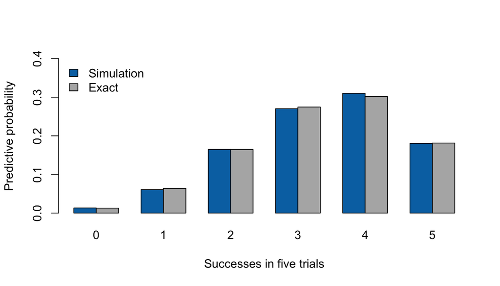

```r
barplot(rbind(s13_simulated, s13_mass), beside = TRUE, names.arg = s13_grid,
        col = c("#0072B2", "grey70"), ylim = c(0, 0.4),
        xlab = "Successes in five trials", ylab = "Predictive probability")
legend("topleft", c("Simulation", "Exact"), fill = c("#0072B2", "grey70"),
       bty = "n")
```

The predictive variance exceeds `5*(2/3)*(1/3)`, the plug-in binomial variance. **Extension:** estimate the probability of five successes and its MCSE, checking against `33/182`. Then use independent parameter draws within each five-trial dataset and compare with `(2/3)^5`.

# Section 1.4 — Marginal and conditional comparisons

**Concept.** When groups have different mixes of departments, their overall rates weight the department-specific rates differently. The overall comparison can reverse the within-department comparisons.

**Example.** Use the hypothetical admissions rates and department weights in the notes. Group 1 applies mostly to the department with the higher admissions rate.

Store rates and application weights in separate matrices, with groups as rows and departments as columns. Sum the weighted rates across departments to obtain each group’s marginal rate.

```r
s14_conditional <- rbind(group1=c(.8,.4), group0=c(.9,.5))
s14_weights <- rbind(group1=c(.9,.1), group0=c(.1,.9))
s14_marginal <- rowSums(s14_conditional*s14_weights)
knitr::kable(cbind(s14_conditional, marginal=s14_marginal),
 col.names=c('Department 1','Department 2','Marginal'))
```

|  | Department 1 | Department 2 | Marginal |
| --- | --- | --- | --- |
| group1 | 0.8 | 0.4 | 0.76 |
| group0 | 0.9 | 0.5 | 0.54 |

```r
stopifnot(max(abs(s14_marginal-c(.76,.54)))<1e-12)
```

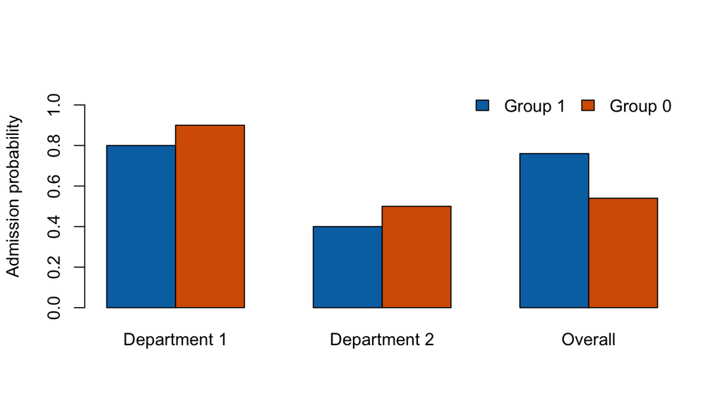

```r
barplot(cbind(s14_conditional, s14_marginal), beside = TRUE,
        names.arg = c("Department 1", "Department 2", "Overall"),
        col = c("#0072B2", "#D55E00"), ylim = c(0, 1.1),
        ylab = "Admission probability")
legend("topright", c("Group 1", "Group 0"), fill = c("#0072B2", "#D55E00"),
       bty = "n", horiz = TRUE)
```

The reversal arises from different department weights. Neither calculation alone identifies a causal effect. **Extension:** standardize both groups to department weights `(0.5,0.5)` and interpret the resulting comparison.

R 4.6.0 · BayesComp 0.1.0